# Lab Two Classification

Australian Weather Station Collection Data 2007-2017

##### Create by An Nguyen, Andy Ho, Jodi Pafford

March 9, 2019

# Data Preparation 1

**Define and prepare your class variables. Use proper variable representations (int, float, one-hot, etc.). Use pre-processing methods (as needed) for dimensionality reduction, scaling, etc. Remove variables that are not needed/useful for the analysis.**

The following shows our pre-processing and final data set to use for training and testing the various measures and models. Summary of our data set can be found in the next section under **Data Preparation 2**. The original data file named 'weatherAus.csv' was outputted as 'rainfall.csv' after our pre-processing. The data set contains daily weather observations from numerous Australian weather stations. The daily observations are available from http://www.bom.gov.au/climate/data. Copyright Commonwealth of Australia 2010, Bureau of Meteorology.

The following is the data meaning types for the features used for Lab Two (19 variables by class type):

- Int64: RainToday, RainTomorrow
- Float64: MinTemp, MaxTemp, Rainfall, WindGustDir, WindGustSpeed, WindDir9am, WindDir3pm, WindSpeed9am, WindSpeed3pm, Humidity9am, Humidity3pm, Pressure9am, Pressure3pm, Cloud9am, Cloud3pm, Temp9am, Temp3pm

Codebook in its entirety can be found at https://www.kaggle.com/jsphyg/weather-dataset-rattle-package.

```python
import pandas as pd
import numpy as np
import matplotlib as mpl
import matplotlib.pyplot as plt
%matplotlib inline

##Load original dataset.  No longer needed.
##The cleaning process is very computationally expensive therefore a the 'ranifall.csv' file was created for later use.
#rainfall_original = pd.read_csv('weatherAus.csv')

#Functions to find the average value using the bracketing values around the NaN's.
    #For instance if a city's 'MinTemp' has 34, 32, NaN, NaN, 55 recorded
    #the function will average 32 and 55 for the first NaN: (32+55)/2 = 43.5
    #and average the above value and 55 for the second NaN: (43.5+55)/2 = 49.25
#Will only use values if they are from the same city.
#If NaN is the earliest timepoint for a given city the next timepoint with no NaN will be given instead of the mean.
#If NaN is the latest timepoint for a given city the previous timepoint with no NaN will be given instead of the mean.

def impute_by_city(cities,variables):
    for c in cities:
        #aPrse out observations from a single city.
        temp = rainfall[rainfall.Location == c]

        #Interate through all observations of the temp data file.
        i = min(temp.index)
        while i <= max(temp.index):
            for v in variables:
                #Check to see if there are values recorded for the variable, will pass over if all are NaN.
                if pd.isna(temp[v]).all():
                    pass

                #Check to see if a single value is NaN.
                elif pd.isna(temp[v][i]):
                    #Find the mean of bracketing values and impute into main dataframe.
                    temp[v][i] = find_mean(temp[v], i)
                    rainfall[v][i] = temp[v][i]
            i = i + 1

#Find mean of bracketing values.
def find_mean(templist, index):
    #If NaN is earliest timepoint for the city take the next value that is not NaN.
    if index == min(templist.index):
        return find_top(templist, index)

    #If latest timepoint for the city take the previous value that is not NaN.
    elif index == max(templist.index):
        return find_bottom(templist, index)

    else:
        #Find previous non-NaN value.
        bottom = find_bottom(templist, index)
        #Find next non-NaN value.
        top = find_top(templist, index)

    #If current value is not from the latest timepoint for the city but there are no more non-NaN value recorded
    #after this value then the previous non-NaN value will be taken.
    if pd.isna(top):
        return bottom


    else:
        mean = (top + bottom)/2
        return mean

#Find previous non-NaN value.
def find_bottom(templist, index):
    while pd.isna(templist[index-1]):
        index = index-1
    bottom = templist[index-1]
    return bottom

#Find next non-NaN value.
#If there are no more non-NaN values return the previous non-NaN value.
def find_top(templist, index):
    while pd.isna(templist[index+1]):
        index = index+1
        if index == max(templist.index):
            top = np.nan
            return top
    top = templist[index+1]
    return top
```

```python
##Code for first run data cleaning, no longer needed after 'rainfall.csv' was created at the end of cleaning process.

#rainfall = rainfall_original.copy()

##'RISK_MM' was used by creator of dataset to extrapolate response variable, 'RainTomorrow.'  Needs to be dropped to not
##influence prediction.
#rainfall.drop(["RISK_MM"], axis=1, inplace=True)

##Drop any observation with no record of rainfall for the day.  Cannot be imputed.
#rainfall.dropna(subset=["RainToday"], inplace=True)

#Reset the Index of each observation to match it's iloc, get rid of gaps between Index integers.
#rainfall = rainfall.reset_index(drop=True)
#rainfall.info()
```

```python
##can be skipped if rainfall.csv already generated!

##set the cardinal directions to degrees.
#directions = {'N':0, 'NNE':22.5, 'NE':45, 'NE':45, 'ENE':67.5, 'E':90, 'ESE':112.5, 'SE':135, 'SSE':157.5, 'S':180,\
#              'SSW':202.5, 'SW':225, 'WSW':247.5, 'W':270, 'WNW':292.5, 'NW':315, 'NNW':337.5}

##Replace cardianl direction to their corresponding degrees.
#rainfall = rainfall.replace(directions)

#Get name of all cities in the data frame.
#cities = rainfall.Location.unique()

#c_variables = []
#d_variables = []

##change 'Yes' and 'No' to 1 and 0 respectively.
#rainfall.RainToday = rainfall.RainToday=='Yes'
#rainfall.RainToday = rainfall.RainToday.astype(np.int)
#rainfall.RainTomorrow = rainfall.RainTomorrow=='Yes'
#rainfall.RainTomorrow = rainfall.RainTomorrow.astype(np.int)

##Find all variables with continous data type.
#for l in list(rainfall):
#    if (rainfall[l].dtypes == 'float64'):
#        c_variables.append(l)
#    else:
#        d_variables.append(l)
```

```python
##can be skipped if rainfall.csv already generated! Very expensive, 'rainfall.csv' can be uploaded from working directory

##Impute values to NaN's and save to csv file for later use.
#impute_by_city(cities, c_variables)
#rainfall.to_csv("rainfall.csv", sep=',', index=True)
```

```
BadgerysCreek
Newcastle
NorahHead
Penrith
Tuggeranong
MountGinini
Nhil
Dartmoor
GoldCoast
Adelaide
Albany
Witchcliffe
SalmonGums
Walpole
```

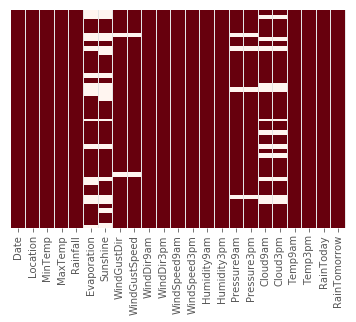

```python
import seaborn as sns

##load pre-generated rainfall.csv file.
rainfall = pd.read_csv('rainfall.csv', index_col=0)

# Visualising missing data:
sns.heatmap(rainfall.isnull(),yticklabels=False,cbar=False,cmap='Reds_r')

#Variables 'Evaporation' and 'Sunshine' contained many missing values, too many to be imputed.
rainfall = rainfall.drop(['Evaporation', 'Sunshine'], axis = 1)

#Get name of all cities in the data frame.
l = list(rainfall.Location.unique())

#Drop all observations with NaN's.  These are values that could not be imputed using the above code.
rainfall.dropna(subset = list(rainfall), inplace = True)

#List all cities that were dropped
for i in l:
    if i not in rainfall.Location.unique():
        print(i)

#'Date' and 'Location' variables not needed for prediction.
rainfall = rainfall.drop(['Date', 'Location'], axis = 1)
```

```
0    79872
1    21456
Name: RainTomorrow, dtype: int64
```

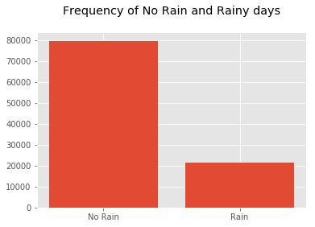

```python
mpl.style.use('ggplot')
plt.figure(figsize=(6,4))
plt.hist(rainfall['RainTomorrow'],bins=2,rwidth=0.8)
plt.xticks([0.25,0.75],['No Rain','Rain'])
plt.title('Frequency of No Rain and Rainy days\n')
print(rainfall['RainTomorrow'].value_counts())
```

```python
rainfall.info()
```

```
<class 'pandas.core.frame.DataFrame'>
Int64Index: 101328 entries, 0 to 140786
Data columns (total 19 columns):
MinTemp          101328 non-null float64
MaxTemp          101328 non-null float64
Rainfall         101328 non-null float64
WindGustDir      101328 non-null float64
WindGustSpeed    101328 non-null float64
WindDir9am       101328 non-null float64
WindDir3pm       101328 non-null float64
WindSpeed9am     101328 non-null float64
WindSpeed3pm     101328 non-null float64
Humidity9am      101328 non-null float64
Humidity3pm      101328 non-null float64
Pressure9am      101328 non-null float64
Pressure3pm      101328 non-null float64
Cloud9am         101328 non-null float64
Cloud3pm         101328 non-null float64
Temp9am          101328 non-null float64
Temp3pm          101328 non-null float64
RainToday        101328 non-null int64
RainTomorrow     101328 non-null int64
dtypes: float64(17), int64(2)
memory usage: 15.5 MB
```

# Data Preparation 2

**Describe the final dataset that is used for classification/regression (include a description of any newly formed variables you created).**

The original data set had 140,787 observations and 24 features. After pre-processing, dimension reduction occurred leaving the new data set at 101,328 observations and 19 features. Observations were removed if it contained any NaNs within its features. The following features were removed:

- Evaporation : Too many NaNs to impute
- Sunshine: Too many NaNs to impute
- Date: Feature not required for classification and/or prediction
- Location: Feature not required since we're predicting rain or not for Australia and not by cities
- RISK_MM: Feature not required since it measures the amount of rain. Would impact modeling results.

We also decided for classification/regression purposes, to convert the "Cardinal Directions" to degrees. For example, N':0, 'NNE':22.5, 'NE':45, 'NE':45, and so on.

The reduction of features will help make our proposed model simpler and mitigate the probabiilty of overfitting. Since the data set has over a hundred thousand observations, we had sufficient number of observations that removing the observations with NaNs would not interfere with our training and test set results (i.e. accuracy).

Further modeling and various evaluations will be required to better understand which measure are most appropriate for analyzing the results of our modeling.

```python
rainfall.shape
```

```
(101328, 19)
```

# Modeling and Evaluation 1

**Choose and explain your evaluation metrics that you will use (i.e., accuracy, precision, recall, F-measure, or any metric we have discussed). Why are the measure(s) appropriate for analyzing the results of your modeling? Give a detailed explanation backing up any assertions.**

For the classification task, we chose to use the F1 calculation as our evaluation metrics. The F1 measure is the weighted average of Precision and Recall. The dataset we are using is not senstive to False Positive like that of a medical study and therefore it is not as important to use Precision and Recall alone. Accuracy is not the best choice when the classes are not close to equal in sizes and therefore not a good fit for this dataset. Class size is demonstrated below. F1 Calculation, 2*(Recall* Precision)/(Recall + Precision), will be used as our evaluation metric of choice.

```
RainTomorrow
0    79872
1    21456
dtype: int64
```

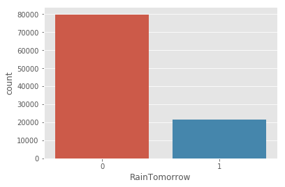

```python
#View size of classes to justify not using accuracy
import seaborn as sns
import matplotlib.pyplot as plt
print(rainfall.groupby('RainTomorrow').size())
sns.countplot(rainfall['RainTomorrow'], label="Count")
plt.show()
```

# Modeling and Evaluation 2

**Choose the method you will use for dividing your data into training and testing splits (i.e., are you using Stratified 10-fold cross validation? Why?). Explain why your chosen method is appropriate or use more than one method as appropriate. For example, if you are using time series data then you should be using continuous training and testing sets across time.**

We chose to divide our data into training and testing splits by using Shuffle Split. By choosing a cross-validation that is not stratified, we are ensuring that the training set never becomes part of the testing set and vice-versa. Additionally, the size of our dataset does not warrant the use of multiple splits for improved accuracy. For this same reason, we chose to only calculate 1 iteration of the split.

```python
from sklearn.model_selection import ShuffleSplit as ss

#Split our data into training and testing sets, 80% of data will be in the training set and 20% the testing set.
#Data will be process this way 5 times, value can be change per user's judgement.  It is recommended that number
#of iterations be at least 2 so that standard deviations can be computed.
num_cv_iterations = 1
cv_object = ss(n_splits=num_cv_iterations, test_size  = 0.2)
```

# Modeling and Evaluation 3

**Create three different classification/regression models for each task (e.g., random forest, KNN, and SVM for task one and the same or different algorithms for task two). Two modeling techniques must be new (but the third could be SVM or logistic regression). Adjust parameters as appropriate to increase generalization performance using your chosen metric. You must investigate different parameters of the algorithms!**

- Task 1 Classification: Predict if it will rain the next day or not.
- Task 2 Regression: Compute how much it rained that day.

## Task 1 Classification: Predict if it will rain the next day or not.

```
F1 Measure of KNN with 1 neighbors with 'uniform' weights is: 0.54259
Time to Run: 28.040334939956665
F1 Measure of KNN with 2 neighbors with 'uniform' weights is: 0.45876
Time to Run: 26.269512176513672
F1 Measure of KNN with 3 neighbors with 'uniform' weights is: 0.56787
Time to Run: 29.83976697921753
F1 Measure of KNN with 4 neighbors with 'uniform' weights is: 0.51091
Time to Run: 30.77919864654541
F1 Measure of KNN with 5 neighbors with 'uniform' weights is: 0.57964
Time to Run: 32.42784357070923
F1 Measure of KNN with 6 neighbors with 'uniform' weights is: 0.54048
Time to Run: 33.91741967201233
F1 Measure of KNN with 7 neighbors with 'uniform' weights is: 0.58562
Time to Run: 35.697470903396606
F1 Measure of KNN with 8 neighbors with 'uniform' weights is: 0.55105
Time to Run: 36.36170148849487
F1 Measure of KNN with 9 neighbors with 'uniform' weights is: 0.59123
Time to Run: 37.01339936256409
F1 Measure of KNN with 10 neighbors with 'uniform' weights is: 0.56078
Time to Run: 38.30052733421326
```

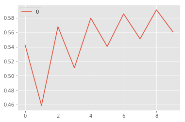

```
The number of neighbors with the highest F1 score is 9, F1 of 0.59123.

F1 Measure of KNN with 1 neighbors with 'distance' weights is: 0.54259
Time to Run: 23.544116020202637
F1 Measure of KNN with 2 neighbors with 'distance' weights is: 0.54259
Time to Run: 27.210474729537964
F1 Measure of KNN with 3 neighbors with 'distance' weights is: 0.56890
Time to Run: 29.03968119621277
F1 Measure of KNN with 4 neighbors with 'distance' weights is: 0.57679
Time to Run: 31.944385528564453
F1 Measure of KNN with 5 neighbors with 'distance' weights is: 0.58100
Time to Run: 32.95711922645569
F1 Measure of KNN with 6 neighbors with 'distance' weights is: 0.58805
Time to Run: 34.356335401535034
F1 Measure of KNN with 7 neighbors with 'distance' weights is: 0.58792
Time to Run: 35.058215618133545
F1 Measure of KNN with 8 neighbors with 'distance' weights is: 0.59220
Time to Run: 36.90672850608826
F1 Measure of KNN with 9 neighbors with 'distance' weights is: 0.59266
Time to Run: 36.87947940826416
F1 Measure of KNN with 10 neighbors with 'distance' weights is: 0.59411
Time to Run: 38.96815013885498
```

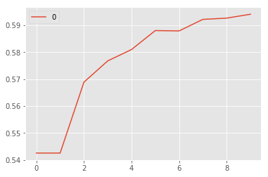

```
The number of neighbors with the highest F1 score is 10, F1 of 0.59411.

F1 Measure of Gausian Naive Bayes is: 0.58363
Time to Run: 0.0813441276550293

F1 Measure of Logistic Regression 'l1' penalty with cost 1 is: 0.60030
Time to Run: 1.381211757659912
F1 Measure of Logistic Regression 'l1' penalty with cost 2 is: 0.60030
Time to Run: 1.35209059715271
F1 Measure of Logistic Regression 'l1' penalty with cost 3 is: 0.60049
Time to Run: 1.3292758464813232
F1 Measure of Logistic Regression 'l1' penalty with cost 4 is: 0.60022
Time to Run: 1.264796257019043
F1 Measure of Logistic Regression 'l1' penalty with cost 5 is: 0.60022
Time to Run: 1.2578949928283691
F1 Measure of Logistic Regression 'l1' penalty with cost 6 is: 0.60041
Time to Run: 1.2558276653289795
F1 Measure of Logistic Regression 'l1' penalty with cost 7 is: 0.60022
Time to Run: 1.2985224723815918
F1 Measure of Logistic Regression 'l1' penalty with cost 8 is: 0.60022
Time to Run: 1.1879713535308838
F1 Measure of Logistic Regression 'l1' penalty with cost 9 is: 0.60041
Time to Run: 1.3099172115325928
F1 Measure of Logistic Regression 'l1' penalty with cost 10 is: 0.60033
Time to Run: 1.5816998481750488
```

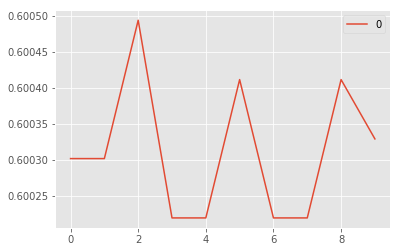

```
The cost with the highest F1 score is 3, F1 of 0.60049.

F1 Measure of Logistic Regression 'l2' penalty with cost 1 is: 0.60030
Time to Run: 0.7955818176269531
F1 Measure of Logistic Regression 'l2' penalty with cost 2 is: 0.60014
Time to Run: 0.7767667770385742
F1 Measure of Logistic Regression 'l2' penalty with cost 3 is: 0.60014
Time to Run: 0.7231645584106445
F1 Measure of Logistic Regression 'l2' penalty with cost 4 is: 0.60014
Time to Run: 0.72713303565979
F1 Measure of Logistic Regression 'l2' penalty with cost 5 is: 0.60014
Time to Run: 0.7196941375732422
F1 Measure of Logistic Regression 'l2' penalty with cost 6 is: 0.60014
Time to Run: 0.7405619621276855
F1 Measure of Logistic Regression 'l2' penalty with cost 7 is: 0.60014
Time to Run: 0.7360265254974365
F1 Measure of Logistic Regression 'l2' penalty with cost 8 is: 0.60014
Time to Run: 0.7350690364837646
F1 Measure of Logistic Regression 'l2' penalty with cost 9 is: 0.60014
Time to Run: 0.7256457805633545
F1 Measure of Logistic Regression 'l2' penalty with cost 10 is: 0.60014
Time to Run: 0.7266385555267334
```

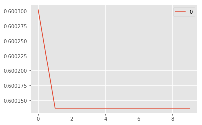

```
The cost with the highest F1 score is 1, F1 of 0.60030.
```

```python
from sklearn import metrics as mt
from sklearn.preprocessing import StandardScaler as sts
from sklearn.linear_model import LogisticRegression as lr
from sklearn.neighbors import KNeighborsClassifier as knnc
from sklearn.naive_bayes import GaussianNB as gnb
import time

#Assign values to response variable, y, and explanatory variables, x.
temp_rainfall = rainfall.copy()
if 'RainTomorrow' in temp_rainfall:
    #Response variable is 'RainTomorrow'
    y = temp_rainfall['RainTomorrow'].values

    #Remove response variable from dataframe
    del temp_rainfall['RainTomorrow']

    #Everything else is the explanatory variables used in prediction.
    x = temp_rainfall.values

scl_obj = sts()

#Split the data into training and testing set 5 different ways, iterate through each way.
for iter_num, (train_indices, test_indices) in enumerate(cv_object.split(x,y)):

    #Standardize the explanatory variables of the training and testing sets' means to be around 0 with a standard deviation of 1.
    #Each value is subtracted from the mean and divided by the standard deviation of the whole dataset.
    scl_obj.fit(x[train_indices])
    X_train_scaled = scl_obj.transform(x[train_indices])
    X_test_scaled = scl_obj.transform(x[test_indices])

    #K Nearest Neighbors, all neighbors are treated the same.  Number of neighbors range from 1 to 10.
    F1_values = []
    for K in range(1, 11):
        t0=time.time()
        knn_clf = knnc(n_neighbors=K, weights='uniform')
        knn_clf.fit(X_train_scaled,y[train_indices])
        y_hat = knn_clf.predict(X_test_scaled)
        F1 = mt.f1_score(y[test_indices],y_hat)
        F1_values.append(F1)
        print('F1 Measure of KNN with %d neighbors with \'uniform\' weights is: %.5f'%(K,F1))
        print ("Time to Run:", time.time()-t0)
    #plotting the F1 scores against k values
    curve = pd.DataFrame(F1_values) #elbow curve
    plt.show(curve.plot())
    print('The number of neighbors with the highest F1 score is %d, F1 of %.5f.' %(F1_values.index(max(F1_values))+1,max(F1_values)))
    print()

    #K Nearest Neighbors, closer neighbors are given more weight.  Number of neighbors range from 1 to 10.
    F1_values = []
    for K in range(1, 11):
        t0=time.time()
        knn_clf = knnc(n_neighbors=K, weights='distance')
        knn_clf.fit(X_train_scaled,y[train_indices])
        y_hat = knn_clf.predict(X_test_scaled)
        F1 = mt.f1_score(y[test_indices],y_hat)
        F1_values.append(F1)
        print('F1 Measure of KNN with %d neighbors with \'distance\' weights is: %.5f'%(K,F1))
        print ("Time to Run:", time.time()-t0)
    #plotting the F1 scores against k values
    curve = pd.DataFrame(F1_values) #elbow curve
    plt.show(curve.plot())
    print('The number of neighbors with the highest F1 score is %d, F1 of %.5f.' %(F1_values.index(max(F1_values))+1,max(F1_values)))
    print()

    #Gaussian Naive Bayes
    t0=time.time()
    gnb_clf = gnb()
    gnb_clf.fit(X_train_scaled,y[train_indices])
    y_hat = gnb_clf.predict(X_test_scaled)
    F1 = mt.f1_score(y[test_indices],y_hat)
    print('F1 Measure of Gausian Naive Bayes is: %.5f' %(F1))
    print ("Time to Run:", time.time()-t0)
    print()


    #Perform Logistic Regression, cost (inverse of regulation strength) range from 1 to 10 and l1 penalty.
    F1_values = []
    for cost in range(1,11):
        t0=time.time()
        lr_clf = lr(penalty='l1', C=cost)
        lr_clf.fit(X_train_scaled,y[train_indices])
        y_hat = lr_clf.predict(X_test_scaled)
        F1 = mt.f1_score(y[test_indices],y_hat)
        F1_values.append(F1)
        print('F1 Measure of Logistic Regression \'l1\' penalty with cost %d is: %.5f' %(cost, F1))
        print ("Time to Run:", time.time()-t0)
    #plotting the F1 scores against cost values
    curve = pd.DataFrame(F1_values) #elbow curve
    plt.show(curve.plot())
    print('The cost with the highest F1 score is %d, F1 of %.5f.' %(F1_values.index(max(F1_values))+1,max(F1_values)))
    print()

    #Perform Logistic Regression, cost (inverse of regulation strength) range from 1 to 10 and l2 penalty.
    F1_values = []
    for cost in range(1,11):
        t0=time.time()
        lr_clf = lr(penalty='l2', C=cost)
        lr_clf.fit(X_train_scaled,y[train_indices])
        y_hat = lr_clf.predict(X_test_scaled)
        F1 = mt.f1_score(y[test_indices],y_hat)
        F1_values.append(F1)
        print('F1 Measure of Logistic Regression \'l2\' penalty with cost %d is: %.5f' %(cost, F1))
        print ("Time to Run:", time.time()-t0)
    #plotting the F1 scores against cost values
    curve = pd.DataFrame(F1_values) #elbow curve
    plt.show(curve.plot())
    print('The cost with the highest F1 score is %d, F1 of %.5f.' %(F1_values.index(max(F1_values))+1,max(F1_values)))
    print()
```

## Task 2 Regression: Compute how much it rained that day.

```
RMSE of KNN with 1 neighbors with 'uniform' weights is: 9.38958
Time to Run: 16.40957260131836
RMSE of KNN with 2 neighbors with 'uniform' weights is: 7.99765
Time to Run: 20.27696132659912
RMSE of KNN with 3 neighbors with 'uniform' weights is: 7.54711
Time to Run: 26.358314752578735
RMSE of KNN with 4 neighbors with 'uniform' weights is: 7.39186
Time to Run: 27.7561252117157
RMSE of KNN with 5 neighbors with 'uniform' weights is: 7.21075
Time to Run: 26.57407546043396
RMSE of KNN with 6 neighbors with 'uniform' weights is: 7.16847
Time to Run: 28.327012300491333
RMSE of KNN with 7 neighbors with 'uniform' weights is: 7.08540
Time to Run: 29.148357629776
RMSE of KNN with 8 neighbors with 'uniform' weights is: 7.03893
Time to Run: 30.037166595458984
RMSE of KNN with 9 neighbors with 'uniform' weights is: 7.01000
Time to Run: 31.40813946723938
RMSE of KNN with 10 neighbors with 'uniform' weights is: 6.97415
Time to Run: 32.17190361022949
RMSE of KNN with 11 neighbors with 'uniform' weights is: 6.96004
Time to Run: 32.96505928039551
RMSE of KNN with 12 neighbors with 'uniform' weights is: 6.90331
Time to Run: 34.321162700653076
RMSE of KNN with 13 neighbors with 'uniform' weights is: 6.83429
Time to Run: 34.63309454917908
RMSE of KNN with 14 neighbors with 'uniform' weights is: 6.80735
Time to Run: 35.46638751029968
RMSE of KNN with 15 neighbors with 'uniform' weights is: 6.80044
Time to Run: 36.067530155181885
RMSE of KNN with 16 neighbors with 'uniform' weights is: 6.78906
Time to Run: 36.36710524559021
RMSE of KNN with 17 neighbors with 'uniform' weights is: 6.79314
Time to Run: 37.4682400226593
RMSE of KNN with 18 neighbors with 'uniform' weights is: 6.79453
Time to Run: 37.751436948776245
RMSE of KNN with 19 neighbors with 'uniform' weights is: 6.77357
Time to Run: 38.537606716156006
RMSE of KNN with 20 neighbors with 'uniform' weights is: 6.77506
Time to Run: 38.802963972091675
RMSE of KNN with 21 neighbors with 'uniform' weights is: 6.78277
Time to Run: 42.5358521938324
RMSE of KNN with 22 neighbors with 'uniform' weights is: 6.77616
Time to Run: 39.63376021385193
RMSE of KNN with 23 neighbors with 'uniform' weights is: 6.78049
Time to Run: 40.421900272369385
RMSE of KNN with 24 neighbors with 'uniform' weights is: 6.80148
Time to Run: 40.729918003082275
RMSE of KNN with 25 neighbors with 'uniform' weights is: 6.79985
Time to Run: 41.28394532203674
RMSE of KNN with 26 neighbors with 'uniform' weights is: 6.77897
Time to Run: 41.88707518577576
RMSE of KNN with 27 neighbors with 'uniform' weights is: 6.76839
Time to Run: 42.42920541763306
RMSE of KNN with 28 neighbors with 'uniform' weights is: 6.76623
Time to Run: 42.823490381240845
RMSE of KNN with 29 neighbors with 'uniform' weights is: 6.76225
Time to Run: 45.45435166358948
RMSE of KNN with 30 neighbors with 'uniform' weights is: 6.77165
Time to Run: 44.50992465019226
```

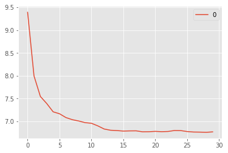

```
The number of neighbors with the lowest RMSE is 29, RMSE of 6.76225.

RMSE of KNN with 1 neighbors with 'distance' weights is: 9.38958
Time to Run: 16.16115713119507
RMSE of KNN with 2 neighbors with 'distance' weights is: 8.00026
Time to Run: 20.182643175125122
RMSE of KNN with 3 neighbors with 'distance' weights is: 7.54269
Time to Run: 23.27328372001648
RMSE of KNN with 4 neighbors with 'distance' weights is: 7.37157
Time to Run: 24.771656274795532
RMSE of KNN with 5 neighbors with 'distance' weights is: 7.19263
Time to Run: 27.182210683822632
RMSE of KNN with 6 neighbors with 'distance' weights is: 7.14453
Time to Run: 28.328426361083984
RMSE of KNN with 7 neighbors with 'distance' weights is: 7.06495
Time to Run: 29.24610209465027
RMSE of KNN with 8 neighbors with 'distance' weights is: 7.01849
Time to Run: 30.179526805877686
RMSE of KNN with 9 neighbors with 'distance' weights is: 6.99010
Time to Run: 30.93593192100525
RMSE of KNN with 10 neighbors with 'distance' weights is: 6.95356
Time to Run: 33.31817173957825
RMSE of KNN with 11 neighbors with 'distance' weights is: 6.93889
Time to Run: 33.08409571647644
RMSE of KNN with 12 neighbors with 'distance' weights is: 6.88670
Time to Run: 35.60178995132446
RMSE of KNN with 13 neighbors with 'distance' weights is: 6.82468
Time to Run: 34.44515347480774
RMSE of KNN with 14 neighbors with 'distance' weights is: 6.79951
Time to Run: 35.32895278930664
RMSE of KNN with 15 neighbors with 'distance' weights is: 6.79044
Time to Run: 35.845359086990356
RMSE of KNN with 16 neighbors with 'distance' weights is: 6.77890
Time to Run: 36.473716259002686
RMSE of KNN with 17 neighbors with 'distance' weights is: 6.78102
Time to Run: 37.71875619888306
RMSE of KNN with 18 neighbors with 'distance' weights is: 6.78134
Time to Run: 37.714242458343506
RMSE of KNN with 19 neighbors with 'distance' weights is: 6.76194
Time to Run: 38.56537103652954
RMSE of KNN with 20 neighbors with 'distance' weights is: 6.76242
Time to Run: 38.761260986328125
RMSE of KNN with 21 neighbors with 'distance' weights is: 6.76789
Time to Run: 39.72903847694397
RMSE of KNN with 22 neighbors with 'distance' weights is: 6.76218
Time to Run: 44.20884895324707
RMSE of KNN with 23 neighbors with 'distance' weights is: 6.76549
Time to Run: 40.13918685913086
RMSE of KNN with 24 neighbors with 'distance' weights is: 6.78381
Time to Run: 41.14256691932678
RMSE of KNN with 25 neighbors with 'distance' weights is: 6.78225
Time to Run: 41.18578743934631
RMSE of KNN with 26 neighbors with 'distance' weights is: 6.76388
Time to Run: 43.043702363967896
RMSE of KNN with 27 neighbors with 'distance' weights is: 6.75470
Time to Run: 42.48727536201477
RMSE of KNN with 28 neighbors with 'distance' weights is: 6.75290
Time to Run: 42.48873996734619
RMSE of KNN with 29 neighbors with 'distance' weights is: 6.74914
Time to Run: 43.29124116897583
RMSE of KNN with 30 neighbors with 'distance' weights is: 6.75697
Time to Run: 43.4504816532135
```

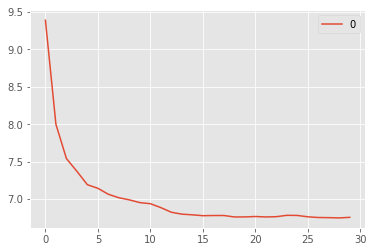

```
The number of neighbors with the lowest RMSE is 29, RMSE of 6.74914.

RMSE of Decision Tree with 2 depth is: 7.23070
Time to Run: 0.14780712127685547
RMSE of Decision Tree with 3 depth is: 7.05660
Time to Run: 0.1681978702545166
RMSE of Decision Tree with 4 depth is: 6.91345
Time to Run: 0.20783281326293945
RMSE of Decision Tree with 5 depth is: 6.90845
Time to Run: 0.24301409721374512
RMSE of Decision Tree with 6 depth is: 6.90714
Time to Run: 0.28522610664367676
RMSE of Decision Tree with 7 depth is: 6.86522
Time to Run: 0.32932400703430176
RMSE of Decision Tree with 8 depth is: 7.37860
Time to Run: 0.3700220584869385
RMSE of Decision Tree with 9 depth is: 7.36827
Time to Run: 0.4146578311920166
```

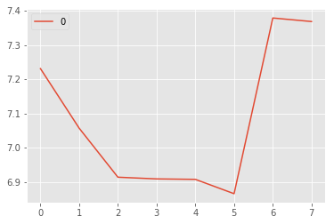

```
The depth with the lowest RMSE is 7, RMSE of 6.86522.

RMSE of Support Vector Regression with epsilon = 0.1 is: 7.15733
Time to Run: 1404.723875761032
RMSE of Support Vector Regression with epsilon = 0.2 is: 7.15491
Time to Run: 552.5976202487946
RMSE of Support Vector Regression with epsilon = 0.3 is: 7.15372
Time to Run: 446.8179693222046
RMSE of Support Vector Regression with epsilon = 0.4 is: 7.15158
Time to Run: 428.8214282989502
RMSE of Support Vector Regression with epsilon = 0.5 is: 7.14812
Time to Run: 275.4539866447449
RMSE of Support Vector Regression with epsilon = 0.6 is: 7.14469
Time to Run: 213.86499786376953
RMSE of Support Vector Regression with epsilon = 0.7 is: 7.14008
Time to Run: 182.2224042415619
RMSE of Support Vector Regression with epsilon = 0.8 is: 7.13704
Time to Run: 163.06356000900269
RMSE of Support Vector Regression with epsilon = 0.9 is: 7.13497
Time to Run: 156.4414300918579
```

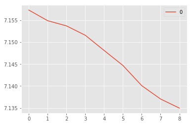

```
The depth with the lowest RMSE is 9, RMSE of 7.13497.
```

```python
from sklearn.neighbors import KNeighborsRegressor as knnr
from sklearn.metrics import mean_squared_error as mse
from sklearn.tree import DecisionTreeRegressor as dtr
from sklearn.svm import SVR

if 'Rainfall' in temp_rainfall:
    #Response variable is 'RainTomorrow'
    y = temp_rainfall['Rainfall'].values

    #Remove response variable from dataframe
    del temp_rainfall['Rainfall']

    #Everything else is the explanatory variables used in prediction.
    x = temp_rainfall.values

scl_obj = sts()

#Split the data into training and testing set 5 different ways, iterate through each way.
for iter_num, (train_indices, test_indices) in enumerate(cv_object.split(x,y)):

    #Standardize the explanatory variables of the training and testing sets' means to be around 0 with a standard deviation of 1.
    #Each value is subtracted from the mean and divided by the standard deviation of the whole dataset.
    scl_obj.fit(x[train_indices])
    X_train_scaled = scl_obj.transform(x[train_indices])
    X_test_scaled = scl_obj.transform(x[test_indices])

    rmse_val = []
    for K in range(1,31):
        t0=time.time()
        knnr_clf = knnr(n_neighbors=K, weights='uniform')
        knnr_clf.fit(X_train_scaled,y[train_indices])
        y_hat = knnr_clf.predict(X_test_scaled)
        error = np.sqrt(mse(y[test_indices],y_hat))
        rmse_val.append(error)
        print('RMSE of KNN with %d neighbors with \'uniform\' weights is: %.5f'%(K,error))
        print ("Time to Run:", time.time()-t0)
    #plotting the rmse values against k values
    curve = pd.DataFrame(rmse_val) #elbow curve
    plt.show(curve.plot())
    print('The number of neighbors with the lowest RMSE is %d, RMSE of %.5f.' %(rmse_val.index(min(rmse_val))+1,min(rmse_val)))
    print()

    rmse_val = []
    for K in range(1,31):
        t0=time.time()
        knnr_clf = knnr(n_neighbors=K, weights='distance')
        knnr_clf.fit(X_train_scaled,y[train_indices])
        y_hat = knnr_clf.predict(X_test_scaled)
        error = np.sqrt(mse(y[test_indices],y_hat))
        rmse_val.append(error)
        print('RMSE of KNN with %d neighbors with \'distance\' weights is: %.5f'%(K,error))
        print ("Time to Run:", time.time()-t0)
    #plotting the rmse values against k values
    curve = pd.DataFrame(rmse_val) #elbow curve
    plt.show(curve.plot())
    print('The number of neighbors with the lowest RMSE is %d, RMSE of %.5f.' %(rmse_val.index(min(rmse_val))+1,min(rmse_val)))
    print()

    rmse_val = []
    for K in range(2,10):
        t0=time.time()
        dtr_clf = dtr(max_depth = K)
        dtr_clf.fit(X_train_scaled,y[train_indices])
        y_hat = dtr_clf.predict(X_test_scaled)
        error = np.sqrt(mse(y[test_indices],y_hat))
        rmse_val.append(error)
        print('RMSE of Decision Tree with %d depth is: %.5f'%(K,error))
        print ("Time to Run:", time.time()-t0)
    #plotting the rmse values against k values
    curve = pd.DataFrame(rmse_val) #elbow curve
    plt.show(curve.plot())
    print('The depth with the lowest RMSE is %d, RMSE of %.5f.' %(rmse_val.index(min(rmse_val))+2,min(rmse_val)))
    print()

    rmse_val = []
    for e in np.arange(.1,1,.1):
        t0=time.time()
        svr_clf = SVR(epsilon=e)
        svr_clf.fit(X_train_scaled,y[train_indices])
        y_hat = svr_clf.predict(X_test_scaled)
        error = np.sqrt(mse(y[test_indices],y_hat))
        rmse_val.append(error)
        print('RMSE of Support Vector Regression with epsilon = %.1f is: %.5f'%(e,error))
        print ("Time to Run:", time.time()-t0)
    #plotting the rmse values against k values
    curve = pd.DataFrame(rmse_val) #elbow curve
    plt.show(curve.plot())
    print('The depth with the lowest RMSE is %d, RMSE of %.5f.' %(rmse_val.index(min(rmse_val))+1,min(rmse_val)))
    print()
```

# Modeling and Evaluation 4

**Analyze the results using your chosen method of evaluation. Use visualizations of the results to bolster the analysis. Explain any visuals and analyze why they are interesting to someone that might use this model.**

## Task 1 Classification: Predict if it will rain the next day or not.

Logistic regression with a low cost results in the best F1 score, 60.0%. Predicting rain for the next day with atmospheric data from the present day using the dataset downloaded is best done with logistic regression if maximizing F1 is the only criteria. If we consider computational expenses using an 'l2', ~0.7 seconds, penalty is cheaper than the 'l1' penalty, ~1.3 seconds. Furthermore, the Gaussian Naive Bayes Classification model took 0.08 seconds to run while giving up a little more than 1% predicting power, 58.3% F1 score. Therefore, it is our recomendation to use the **Gaussian Naive Bayes** Classification model for this case study.

```python
from sklearn.naive_bayes import GaussianNB as gnb
from sklearn.preprocessing import StandardScaler as sts
from sklearn import metrics as mt

temp_rainfall = rainfall.copy()
if 'RainTomorrow' in temp_rainfall:
    #Response variable is 'RainTomorrow'
    y = temp_rainfall['RainTomorrow'].values

    #Remove response variable from dataframe
    del temp_rainfall['RainTomorrow']

    #Everything else is the explanatory variables used in prediction.
    x = temp_rainfall.values

for train_indices, test_indices in cv_object.split(x,y):
    scl_obj = sts()
    scl_obj.fit(x[train_indices])
    X_train_scaled_gnb = scl_obj.transform(x[train_indices])
    X_test_scaled_gnb = scl_obj.transform(x[test_indices])
y_train_gnb = y[train_indices]
y_test_gnb = y[test_indices]

gnb_clf = gnb()
gnb_clf.fit(X_train_scaled_gnb,y_train_gnb)
y_hat = gnb_clf.predict(X_test_scaled_gnb)
F1 = mt.f1_score(y_test_gnb,y_hat)
conf = mt.confusion_matrix(y_test_gnb,y_hat)
print("Confusion matrix")
print(conf)
print('F1 Measure of Gausian Naive Bayes is: %.5f' %(F1)) #F1 score will deviate slightly as each run a new training set is used.
```

```
Confusion matrix
[[14053  1876]
 [ 1701  2636]]
F1 Measure of Gausian Naive Bayes is: 0.59577
```

As a visual representation of the different F1 measures, see the graph below.

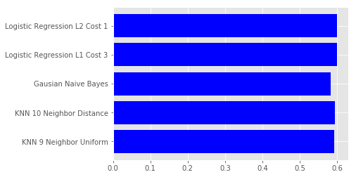

```python
plt.style.use('ggplot')

x = ['KNN 9 Neighbor Uniform', 'KNN 10 Neighbor Distance', 'Gausian Naive Bayes', 'Logistic Regression L1 Cost 3', 'Logistic Regression L2 Cost 1']
energy = [0.59123, 0.59411, 0.58363, 0.60049, 0.60030]

x_pos = [i for i, _ in enumerate(x)]

plt.barh(x_pos, energy, color='blue')

plt.yticks(x_pos, x)

plt.show()
```

Since Naive Bayes treat each feature seperately from the others all features have the same importance. If there are many features it is up to the user to accurately choose the right features. Since our data set only has 18 features we kept all of them in the model.

## Task 2 Regression: Compute how much it rained that day.

K Nearest Neighbors with 29 neighbors results in the best RMSE, 6.75. Predicting the amount of rain for a given day with atmospheric data from that day using the dataset downloaded is best done with KNN if minimizing RMSE is the only criteria. However, if efficiency is also considered using a Decision Tree, less than 1 second, is a better choice than KNN, ~40 seconds. A Decision Tree with a maximum depth of 7 slighly increase the RMSE to 6.87. Therefore, it is our recomendation to use the **Decision Tree model** with a max depth of 7 for this case study.

```python
from sklearn.tree import DecisionTreeRegressor as dtr

if 'Rainfall' in temp_rainfall:
    #Response variable is 'RainTomorrow'
    y = temp_rainfall['Rainfall'].values

    #Remove response variable from dataframe
    del temp_rainfall['Rainfall']

    #Everything else is the explanatory variables used in prediction.
    x = temp_rainfall.values

for train_indices, test_indices in cv_object.split(x,y):
    scl_obj = sts()
    scl_obj.fit(x[train_indices])
    X_train_scaled = scl_obj.transform(x[train_indices])
    X_test_scaled = scl_obj.transform(x[test_indices])
dtr_column_names = temp_rainfall.columns

dtr_clf = dtr(max_depth = 7)
dtr_clf.fit(X_train_scaled,y[train_indices])
y_hat = dtr_clf.predict(X_test_scaled)
error = np.sqrt(mt.mean_squared_error(y[test_indices],y_hat))
print('RMSE of Decision Tree with a max depth of 7 is: %.5f'%(error)) #F1 score will deviate slightly as each run a new training set is used.
```

```
RMSE of Decision Tree with a max depth of 7 is: 7.94658
```

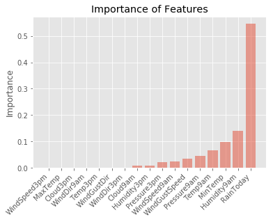

```python
feature_imp = pd.DataFrame(data={'imp': dtr_clf.feature_importances_}, index=dtr_column_names)
feature_imp = feature_imp.sort_values(by=['imp'])

y_pos = np.arange(len(feature_imp))

plt.bar(y_pos, feature_imp['imp'], align='center', alpha=0.5)
plt.xticks(y_pos, feature_imp.index)
plt.xticks(rotation=45, ha='right')
plt.ylabel('Importance')
plt.title('Importance of Features')

plt.show()
```

# Modeling and Evaluation 5

**Discuss the advantages of each model for each classification task, if any. If there are not advantages, explain why. Is any model better than another? Is the difference significant with 95% confidence? Use proper statistical comparison methods. You must use statistical comparison techniques—be sure they are appropriate for your chosen method of validation as discussed in unit 7 of the course.**

```python
gnb_clf = gnb()
gnb_clf.fit(X_train_scaled_gnb,y_train_gnb)
y_hat = gnb_clf.predict(X_test_scaled_gnb)
F1 = mt.f1_score(y_test_gnb,y_hat)
conf = mt.confusion_matrix(y_test_gnb,y_hat)
print("Confusion matrix")
print(conf)
print('F1 Measure of Gausian Naive Bayes is: %.5f' %(F1))
Accuracy = mt.accuracy_score(y_test_gnb,y_hat)
print('Accuracy Measure of Gausian Naive Bayes is: %.5f' %(Accuracy))
```

```
Confusion matrix
[[14101  1875]
 [ 1782  2508]]
F1 Measure of Gausian Naive Bayes is: 0.57835
Accuracy Measure of Gausian Naive Bayes is: 0.81955
```

# Modeling and Evaluation 6

**Which attributes from your analysis are most important? Use proper methods discussed in class to evaluate the importance of different attributes. Discuss the results and hypothesize about why certain attributes are more important than others for a given classification task.**

Naive Bayes opperates on the assumption that there are all pairs of features are independent from each others. Because of this assumption Naive Bayes estimates with each feature decoupled from the rest using one-dimensional distributions resuting in an extremely fast run time. Unfortunately, this same attributes makes it impossible to elucidate out the contribution of each feature. Naive Bayes therefore treats all features with the same weight.

Using tree based feature selection for the regression task, judging from the "Importance of Features" bar chart below, the features of most importance are:

- RainToday
- MinTemp
- Humidity9am

When we compared this with our previous mini-lab of Logistic Regression and SVM, both of which had similiar features of importance - Tree Based feature of importance differed significantly. In LR and SVM, Humidity3pm, Pressure3PM, and Pressure9am were the top 3 features (in identical order of importance). In researching the differences in the three models (SVM, LR, and Tree Based), we concluded that SVM and LR classification accuracy was better than that of Tree Based since both require more computational resource - typically running more kernal types. However, Tree Based algorithms provide in general a good predictive performance, low overfitting, and easy interpretability.

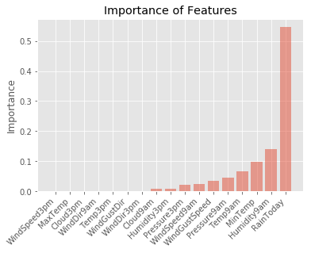

```python
feature_imp = pd.DataFrame(data={'imp': dtr_clf.feature_importances_}, index=dtr_column_names)
feature_imp = feature_imp.sort_values(by=['imp'])

y_pos = np.arange(len(feature_imp))

plt.bar(y_pos, feature_imp['imp'], align='center', alpha=0.5)
plt.xticks(y_pos, feature_imp.index)
plt.xticks(rotation=45, ha='right')
plt.ylabel('Importance')
plt.title('Importance of Features')

plt.show()
```

# Deployment

**How useful is your model for interested parties (i.e., the companies or organizations that might want to use it for prediction)? How would you measure the model's value if it was used by these parties? How would your deploy your model for interested parties? What other data should be collected? How often would the model need to be updated, etc.?**

- Our model would be very useful for any businesses or organizations or individuals that are planning day-to-day activities that can be affected by rain. Farmers need information to help plan for planting and harvesting crops. Airports require rain information to prepare for flight delays and/or cancellations. Weather forecasting in general helps individuals make informed daily decisions (and in some cases, save lives).
- To measure the model's value, we could use some sort of Retroactive Verification or Analysis to log and audit the accuracy of our model. This could include something as simple as "Did it rain when our model said it would?" From there, a business analyst could assign monetary values (both positive and negative) for the organization's decision based on our prediction. In the case of an Airport, if our model predicts rain tomorrow, the business analyst could recommend to the operations director to reduce staff by 10% since there would be flight cancellations - less support required. This would save the airport a great deal of money - the inverse could happen costing the airport a lot of money.
- The model could be deployed in various platforms but we could see this as an API that inserts into the organizations business application database. In general, weather forecasting requires a combination of computer modeling, observation, and a domain expert with knowledge of trends and patterns.
- Ultimately, our model would be a spring board for forecasting out past one day. As most organizations need maximum time to plan, we would need to collect more data aside from what is currently in this example. A couple that come to mind would be satellite imagery to observe cloud patterns around the world or the use of radar to measure precipitation. We could also gather previous patterns and trends from last year or year's past to gauge similarities and differences.
- Initially, the model would need to be updated weekly and up until we can get to a goal of 80% accuracy. This could take months to years as climate is constantly changing, which effects the prediction of rain. Our guess would be the model will require periodic changes and never stops changing as the prediction accuracy could flutuate.

# Exceptional Work

**You have free reign to provide additional analyses. One idea: grid search parameters in a parallelized fashion and visualize the performances across attributes. Which parameters are most significant for making a good model for each classification algorithm**

```python
import numpy as np
from sklearn import decomposition, datasets
from sklearn.preprocessing import StandardScaler
from sklearn.decomposition import PCA
from sklearn import metrics as mt
from sklearn.preprocessing import StandardScaler as sts
from sklearn.linear_model import LogisticRegression as lr
from sklearn.neighbors import KNeighborsClassifier as knnc
from sklearn.naive_bayes import GaussianNB as gnb
import time
```

In order to investigate another method, we chose to do a PCA to summarize our findings in 2 features, Principal Component 1 and 2. By performing a Principal Component analysis, we are able to normalize some of the data to two components.

```python
features = ['MinTemp', 'MaxTemp','Rainfall','WindGustDir','WindGustSpeed','WindDir9am','WindDir3pm','WindSpeed9am','WindSpeed3pm','Humidity9am','Humidity3pm','Pressure9am','Pressure3pm','Cloud9am','Cloud3pm','Temp9am','Temp3pm','RainToday']

x=rainfall.loc[:, features].values
y=rainfall.loc[:,['RainTomorrow']].values

X=StandardScaler().fit_transform(x)
```

```python
pca = PCA(n_components=2)
principalComponents = pca.fit_transform(x)
principalDF = pd.DataFrame(data=principalComponents, columns = ['principal component 1', 'principal component 2'])

finalDF=pd.concat([principalDF, rainfall[['RainTomorrow']]], axis=1)
```

```python
finalDF
```

|  | principal component 1 | principal component 2 | RainTomorrow |
| --- | --- | --- | --- |
| 0 | 192.003583 | 11.412400 | 0.0 |
| 1 | 212.297923 | 84.833333 | 0.0 |
| 2 | 150.447945 | 37.277610 | 0.0 |
| 3 | -138.541512 | 41.439356 | 0.0 |
| 4 | 105.050036 | -170.804494 | 0.0 |
| 5 | 192.407788 | 16.690704 | 0.0 |
| 6 | 155.871387 | -16.834971 | 0.0 |
| 7 | 122.203644 | -74.097662 | 0.0 |
| 8 | 180.825311 | -130.445114 | 1.0 |
| 9 | 66.133173 | -0.778985 | 0.0 |
| 10 | -142.192674 | 59.786553 | 1.0 |
| 11 | -209.047659 | -15.182689 | 1.0 |
| 12 | 253.573616 | 50.308797 | 1.0 |
| 13 | 110.119656 | 64.848312 | 0.0 |
| 14 | -89.827402 | 97.431116 | 1.0 |
| 15 | 59.060874 | -216.160156 | 1.0 |
| 16 | 69.402362 | 48.857945 | 0.0 |
| 17 | 80.301127 | -100.591469 | 0.0 |
| 18 | -26.472406 | -8.580323 | 0.0 |
| 19 | -236.804995 | 7.934684 | 0.0 |
| 20 | 192.042812 | 16.806195 | 0.0 |
| 21 | -43.327806 | -74.875959 | 0.0 |
| 22 | 88.630643 | -131.691293 | 0.0 |
| 23 | 83.055118 | -77.818268 | 0.0 |
| 24 | 63.496045 | -145.825421 | 0.0 |
| 25 | 71.868052 | -223.862736 | 0.0 |
| 26 | 201.126730 | 65.614117 | 1.0 |
| 27 | 155.408242 | 21.764604 | 0.0 |
| 28 | 202.737452 | 30.237999 | 0.0 |
| 29 | 205.951119 | 5.881744 | 0.0 |
| ... | ... | ... | ... |
| 140757 | NaN | NaN | 0.0 |
| 140758 | NaN | NaN | 0.0 |
| 140759 | NaN | NaN | 0.0 |
| 140760 | NaN | NaN | 0.0 |
| 140761 | NaN | NaN | 0.0 |
| 140762 | NaN | NaN | 0.0 |
| 140763 | NaN | NaN | 0.0 |
| 140764 | NaN | NaN | 0.0 |
| 140765 | NaN | NaN | 0.0 |
| 140766 | NaN | NaN | 0.0 |
| 140767 | NaN | NaN | 0.0 |
| 140768 | NaN | NaN | 0.0 |
| 140769 | NaN | NaN | 0.0 |
| 140770 | NaN | NaN | 0.0 |
| 140771 | NaN | NaN | 0.0 |
| 140772 | NaN | NaN | 0.0 |
| 140773 | NaN | NaN | 0.0 |
| 140774 | NaN | NaN | 0.0 |
| 140775 | NaN | NaN | 0.0 |
| 140776 | NaN | NaN | 0.0 |
| 140777 | NaN | NaN | 0.0 |
| 140778 | NaN | NaN | 0.0 |
| 140779 | NaN | NaN | 0.0 |
| 140780 | NaN | NaN | 0.0 |
| 140781 | NaN | NaN | 0.0 |
| 140782 | NaN | NaN | 0.0 |
| 140783 | NaN | NaN | 0.0 |
| 140784 | NaN | NaN | 0.0 |
| 140785 | NaN | NaN | 0.0 |
| 140786 | NaN | NaN | 0.0 |

129156 rows × 3 columns

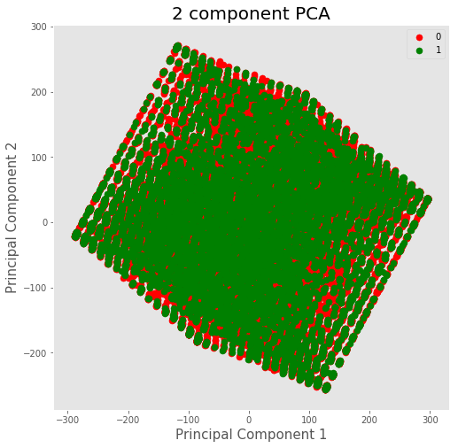

```python
fig = plt.figure(figsize = (8,8))
ax = fig.add_subplot(1,1,1)
ax.set_xlabel('Principal Component 1', fontsize = 15)
ax.set_ylabel('Principal Component 2', fontsize = 15)
ax.set_title('2 component PCA', fontsize = 20)
targets = [0, 1]
colors = ['r', 'g']
for target, color in zip(targets,colors):
    indicesToKeep = finalDF['RainTomorrow'] == target
    ax.scatter(finalDF.loc[indicesToKeep, 'principal component 1']
               , finalDF.loc[indicesToKeep, 'principal component 2']
               , c = color
               , s = 50)
ax.legend(targets)
ax.grid()
```

The variance ration is explained below. PC1 contains 56.4% of the variance and PC2 contains 25.5% of the variance. This model combined contains 81.9% of the information. However, we can see that PC1 contains significantly more than PC2.

```python
pca.explained_variance_ratio_
```

```
array([0.5638658 , 0.25521543])
```